# NeStage Functions: A User Guide

# 5 Running Ne_sexual_Y2000: a complete worked example

## 5.1 All inputs explained

```r
Ne_sexual_Y2000(
  T_mat      = MatU,        # MatU: survival/transition matrix (s x s)
                             # Column sums must be <= 1
  F_vec      = MatF[1, ],   # First row of MatF: per-capita offspring
                             # production for each stage
  D          = D,           # Stage frequency vector, length s, sums to 1
                             # Use observed proportions or dominant eigenvector
  Vk_over_k  = rep(1, s),  # Variance-to-mean ratio of sexual reproductive
                             # output per stage. Default = 1 (Poisson).
                             # Set > 1 if some individuals dominate reproduction.
  a          = 0,           # Deviation from Hardy-Weinberg proportions.
                             # Default = 0 (random mating).
  L          = NULL,        # Generation time. If NULL, computed from T_mat
                             # and F_vec automatically.
  Ne_target  = 50,        # Ne viability threshold. Set to your study system:
                             #   50  = avoid inbreeding depression (Franklin 1980)
                             #   500 = maintain quantitative variation (Franklin 1980)
                             #   5000 = long-term evolutionary potential (Lande 1995)
  census_N   = 40,        # Your actual (or expected) census population size.
                             # Reports Ne_at_census = NeN * census_N directly,
                             # so you can see the Ne your population achieves NOW.
  population = "my pop"     # Label for output
)
```

## 5.2 Full output for *L. rupestris* population 1

```r
Ne_Lrup1 <- Ne_sexual_Y2000(
  T_mat      = MatU_Lrup1_mo,
  F_vec      = MatF_Lrup1_mo[1, ],
  D          = D_Lrup1,
  Ne_target  = 50,         # short-term inbreeding threshold
  census_N   = 40,         # realistic large population of Lepanthes
  population = "L. rupestris population 1 (monthly)"
)

print(Ne_Lrup1)
```

```
#>
#> === NeStage: Sexual population Ne (Yonezawa 2000, Eq. 6, d=0) ===
#>   Population  : L. rupestris population 1 (monthly)
#>   Model       : sexual_Y2000
#>
#>   --- Stage survival ---
#>     u_{.stage_1} = 0.7380
#>     u_{.stage_2} = 0.7780
#>     u_{.stage_3} = 0.9200
#>     u_{.stage_4} = 0.7880
#>     u_{.stage_5} = 0.9750
#>     u_{.stage_6} = 0.9740
#>     u_bar  (population mean annual survival)          = 0.889045
#>     u2_bar (stage-weighted mean of squared survivals) = 0.799244
#>
#>   --- Reproductive parameters ---
#>     a (Hardy-Weinberg deviation)                      = 0.0000
#>     Vk/k_bar (stage_1) = 1.0000
#>     Vk/k_bar (stage_2) = 1.0000
#>     Vk/k_bar (stage_3) = 1.0000
#>     Vk/k_bar (stage_4) = 1.0000
#>     Vk/k_bar (stage_5) = 1.0000
#>     Vk/k_bar (stage_6) = 1.0000
#>     Avr(S) (recruitment-weighted mean S_i)            = 2.000000
#>
#>   --- Variance decomposition ---
#>     V component 1 (between-stage survival variance)   = 0.017687
#>     V component 2 (reproductive variance)             = 0.221911
#>     V total                                           = 0.239598
#>
#>   --- Generation time ---
#>     L = 40.240 yr  [source: computed]
#>
#>   --- Effective size ratio ---
#>     Ne/N (generation-time, Eq. 6) = 0.207
#>     Note: Ny/N is not defined for purely sexual populations.
#>
#>   --- Conservation threshold ---
#>     Ne target              = 50 (minimum Ne for viability)
#>     Minimum census size N  = 242
#>     (Ne/N = 0.207 => need N >= 242 for Ne >= 50)
#>     Ne at your census size (N = 40) = 8.3
#>     WARNING: Ne (8.3) < Ne target (50) at N = 40
```

## 5.3 Reading the output

**Stage survival** reports the annual survival rates and the two key summary statistics: $\bar{u}$ (population-mean annual survival) and $\bar{u^2}$ (stage-weighted mean of squared survivals). The difference $\bar{u} - \bar{u^2}$ measures the **between-stage variance in survival** — stages with very different survival rates contribute more to genetic drift.

**Generation time** $L$ is the mean age of reproduction, computed following Orive (1993), using the dominant eigenvector of $\mathbf{A}$ as the stable-stage distribution.

**Effective size ratios** give the key conservation outputs: - $N_e/N$ — the fraction of census individuals contributing to the effective population. Values below 0.10 are below the empirical median across 102 wildlife species (Frankham 1995). - Minimum census size $N$ required to achieve $N_e \geq 50$ (Franklin 1980).

# 6 All populations of all three species

## 6.1 Entering all matrices

```r
# ============================================================
# L. rupestris — 7 populations, 6-stage model
# Monthly MatU and MatF from Tremblay & Ackerman (2001) Appendix
# ============================================================

# Helper: build MatF from fecundity values for stages 5 and 6
make_MatF_6 <- function(f5, f6) {
  F <- matrix(0, 6, 6)
  F[1, 5] <- f5
  F[1, 6] <- f6
  F  # MatF contains fecundity only — no diagonal terms
}

# Helper: build MatU for L. rupestris (6-stage, shared structure)
# Fixed positions: row1=0, row2 col1=0.738 col2=0.738, row4 col2=0.038,
#                  row5 col2=0.002
# Free parameters (13 values, in row order):
#   row3: s33, s35, s36
#   row4: s43, s44
#   row5: s53, s54, s55, s56
#   row6: s63, s64, s65, s66
make_MatU_Lrup <- function(s33, s35, s36,
                            s43, s44,
                            s53, s54, s55, s56,
                            s63, s64, s65, s66) {
  matrix(c(
    0,     0,     0,    0,    0,    0,
    0.738, 0.738, 0,    0,    0,    0,
    0,     0,     s33,  0,    s35,  s36,
    0,     0.038, s43,  s44,  0,    0,
    0,     0.002, s53,  s54,  s55,  s56,
    0,     0,     s63,  s64,  s65,  s66
  ), nrow = 6, byrow = TRUE,
  dimnames = list(paste0("stage_", 1:6), paste0("stage_", 1:6)))
}

# --- L. rupestris population 1 (already defined above) ---
MatU_Lrup <- list()
MatF_Lrup <- list()
MatU_Lrup[[1]] <- MatU_Lrup1_mo
MatF_Lrup[[1]] <- MatF_Lrup1_mo

# --- L. rupestris population 2 ---
MatU_Lrup[[2]] <- make_MatU_Lrup(
  0.466, 0.126, 0.028,   # row 3: s33, s35, s36
  0,     0.777,           # row 4: s43, s44
  0.491, 0.011, 0.750, 0.191,  # row 5
  0.022, 0,     0.112, 0.781   # row 6
)
MatF_Lrup[[2]] <- make_MatF_6(0.086, 0.273)

# --- L. rupestris population 3 ---
MatU_Lrup[[3]] <- make_MatU_Lrup(
  0.653, 0.100, 0.035,
  0,     0.777,
  0.307, 0.011, 0.794, 0.338,
  0.009, 0,     0.101, 0.627
)
MatF_Lrup[[3]] <- make_MatF_6(0.076, 0.204)

# --- L. rupestris population 4 ---
MatU_Lrup[[4]] <- make_MatU_Lrup(
  0.600, 0.101, 0.018,
  0,     0.777,
  0.310, 0.011, 0.740, 0.225,
  0.033, 0,     0.150, 0.744
)
MatF_Lrup[[4]] <- make_MatF_6(0.076, 0.204)

# --- L. rupestris population 5 ---
MatU_Lrup[[5]] <- make_MatU_Lrup(
  0.596, 0.153, 0.018,
  0,     0.777,
  0.348, 0.011, 0.728, 0.286,
  0.000, 0,     0.082, 0.688
)
MatF_Lrup[[5]] <- make_MatF_6(0.041, 0.165)

# --- L. rupestris population 6 ---
MatU_Lrup[[6]] <- make_MatU_Lrup(
  0.528, 0.133, 0.020,
  0,     0.777,
  0.375, 0.011, 0.695, 0.218,
  0.040, 0,     0.140, 0.749
)
MatF_Lrup[[6]] <- make_MatF_6(0.066, 0.315)

# --- L. rupestris population 7 ---
MatU_Lrup[[7]] <- make_MatU_Lrup(
  0.635, 0.224, 0.058,
  0,     0.777,
  0.333, 0.011, 0.695, 0.299,
  0.018, 0,     0.070, 0.643
)
MatF_Lrup[[7]] <- make_MatF_6(0.119, 0.507)

# Stage frequencies for L. rupestris (Table 1, split equally across stage pairs)
# Seedlings / Juveniles / Adults from Table 1
N_Lrup_raw <- list(
  c(44, 72, 97),   # pop 1
  c(40, 135, 86),  # pop 2
  c(66, 74, 95),   # pop 3
  c(14, 8,  74),   # pop 4
  c(28, 6,  62),   # pop 5
  c(66, 33, 98),   # pop 6
  c(107, 39, 102)  # pop 7
)

D_Lrup <- lapply(N_Lrup_raw, function(n) {
  expanded <- c(n[1]/2, n[1]/2, n[2]/2, n[2]/2, n[3]/2, n[3]/2)
  expanded / sum(expanded)
})

# ============================================================
# L. rubripetala — 6 populations, 5-stage model
# ============================================================
# make_MatU_Lrub: 5-stage MatU for L. rubripetala and L. eltoroensis
# Fixed elements: row2 col1=0.667, col2=0.667; row4 col2=0.037, col4=0.812
# Free parameters:
#   s33 = stage3 -> stage3 (stasis)
#   s35 = stage5 -> stage3 (retrogression from repro to juvenile)
#   s53 = stage3 -> stage5 (growth to reproductive)
#   s54 = stage4 -> stage5 (growth from non-repro adult)
#   s55 = stage5 -> stage5 (stasis in reproductive stage)
make_MatU_Lrub <- function(s33, s35,
                             s53, s54, s55) {
  matrix(c(
    0,     0,     0,     0,     0,
    0.667, 0.667, 0,     0,     0,
    0,     0,     s33,   0,     s35,
    0,     0.037, 0,     0.812, 0,
    0,     0,     s53,   s54,   s55
  ), nrow = 5, byrow = TRUE,
  dimnames = list(paste0("stage_", 1:5), paste0("stage_", 1:5)))
}

make_MatF_5 <- function(f5) {
  F <- matrix(0, 5, 5)
  F[1, 5] <- f5
  F  # MatF contains fecundity only — no diagonal terms
}

MatU_Lrub <- list()
MatF_Lrub <- list()

MatU_Lrub[[1]] <- make_MatU_Lrub(0.825, 0.227, 0.137, 0.010, 0.739)
MatU_Lrub[[2]] <- make_MatU_Lrub(0.546, 0.183, 0.426, 0.010, 0.793)
MatU_Lrub[[3]] <- make_MatU_Lrub(0.606, 0.137, 0.337, 0.010, 0.848)
MatU_Lrub[[4]] <- make_MatU_Lrub(0.743, 0.180, 0.176, 0.010, 0.768)
MatU_Lrub[[5]] <- make_MatU_Lrub(0.726, 0.250, 0.237, 0.010, 0.739)
MatU_Lrub[[6]] <- make_MatU_Lrub(0.801, 0.179, 0.131, 0.010, 0.784)

MatF_Lrub[[1]] <- make_MatF_5(0.043)
MatF_Lrub[[2]] <- make_MatF_5(0.102)
MatF_Lrub[[3]] <- make_MatF_5(0.108)
MatF_Lrub[[4]] <- make_MatF_5(0.067)
MatF_Lrub[[5]] <- make_MatF_5(0.067)
MatF_Lrub[[6]] <- make_MatF_5(0.159)

# Stage frequencies (Table 1): seedlings / juveniles / adults (one repro stage)
# For 5-stage model: stages 1-2 = seedlings/2, stages 3-4 = juveniles/2,
#                    stage 5 = adults
N_Lrub_raw <- list(
  c(9,  44, 101),  # pop 1
  c(0,  0,  27),   # pop 2 — no seedlings/juveniles observed
  c(5,  29, 63),   # pop 3
  c(37, 49, 41),   # pop 4
  c(52, 4,  46),   # pop 5
  c(24, 10, 29)    # pop 6
)

# For populations with missing stage observations, derive D from the
# stable stage distribution (dominant eigenvector of A = MatU + MatF)
  # — only used for L. rubripetala pop 2 where no seedlings or juveniles
  # were observed, so observed D cannot be constructed.
# This is standard practice when observed counts are incomplete.
D_Lrub <- lapply(seq_along(N_Lrub_raw), function(i) {
  n <- N_Lrub_raw[[i]]
  if (all(n[1:2] == 0)) {
    # No seedlings/juveniles observed — use stable stage distribution
    A <- MatU_Lrub[[i]] + MatF_Lrub[[i]]
    ev <- Re(eigen(A)$vectors[, 1])
    ev <- abs(ev)
    ev / sum(ev)
  } else {
    expanded <- c(n[1]/2, n[1]/2, n[2]/2, n[2]/2, n[3])
    expanded / sum(expanded)
  }
})

# ============================================================
# L. eltoroensis — 4 populations, 5-stage model (same structure as L. rubripetala)
# ============================================================
MatU_Lelt <- list()
MatF_Lelt <- list()

MatU_Lelt[[1]] <- matrix(c(
    0,     0,     0,     0,     0,
    0.667, 0.667, 0,     0,     0,
    0,     0,     0.719, 0,     0.274,
    0,     0.037, 0,     0.958, 0,
    0,     0,     0.258, 0.021, 0.720
  ), nrow=5, byrow=TRUE, dimnames=list(paste0("stage_",1:5), paste0("stage_",1:5)))
MatU_Lelt[[2]] <- matrix(c(
    0,     0,     0,     0,     0,
    0.667, 0.667, 0,     0,     0,
    0,     0,     0.696, 0,     0.255,
    0,     0.037, 0,     0.958, 0,
    0,     0,     0.304, 0.021, 0.742
  ), nrow=5, byrow=TRUE, dimnames=list(paste0("stage_",1:5), paste0("stage_",1:5)))
MatU_Lelt[[3]] <- matrix(c(
    0,     0,     0,     0,     0,
    0.667, 0.667, 0,     0,     0,
    0,     0,     0.759, 0,     0.406,
    0,     0.037, 0,     0.958, 0,
    0,     0,     0.222, 0.021, 0.589
  ), nrow=5, byrow=TRUE, dimnames=list(paste0("stage_",1:5), paste0("stage_",1:5)))
# Population 4: substitute L. rubripetala seedling transitions (as in paper)
MatU_Lelt[[4]] <- matrix(c(
    0,     0,     0,     0,     0,
    0.667, 0.667, 0,     0,     0,
    0,     0,     0.719, 0,     0.274,
    0,     0.037, 0,     0.958, 0,
    0,     0,     0.258, 0.021, 0.720
  ), nrow=5, byrow=TRUE, dimnames=list(paste0("stage_",1:5), paste0("stage_",1:5)))

MatF_Lelt[[1]] <- make_MatF_5(0.011)
MatF_Lelt[[2]] <- make_MatF_5(0.016)
MatF_Lelt[[3]] <- make_MatF_5(0.024)
MatF_Lelt[[4]] <- make_MatF_5(0.011)  # use pop 1 fecundity as substitute

# Stage frequencies (Table 1): juveniles and adults only (no seedlings observed)
N_Lelt_raw <- list(
  c(7,  42),   # pop 1: juveniles, adults
  c(8,  51),   # pop 2
  c(7,  43),   # pop 3
  c(5,  14)    # pop 4
)

# L. eltoroensis: no seedlings observed in any population.
# Stages 1-2 assigned 1% of total N each (small but non-zero);
# stages 3-4 split juveniles equally; stage 5 = adults.
# This preserves the observed juvenile:adult ratio while keeping
# D biologically grounded rather than using the eigenvector,
# which distorts Ne/N when lambda departs from 1.
D_Lelt <- lapply(seq_along(N_Lelt_raw), function(i) {
  n    <- N_Lelt_raw[[i]]
  tot  <- sum(n)
  expanded <- c(0.01*tot, 0.01*tot,  # stages 1-2: small non-zero
                n[1]/2, n[1]/2,       # stages 3-4: juveniles split
                n[2])                 # stage 5: adults
  expanded / sum(expanded)
})
```

## 6.2 Computing Ne/N for all 17 populations

```r
# census_N = 40: a large Lepanthes population (Tremblay & Ackerman 2001)
run_Ne <- function(MatU_list, MatF_list, D_list, species_name,
                   census_N = 40, Ne_target = 50) {
  purrr::map_dfr(seq_along(MatU_list), function(i) {
    r <- Ne_sexual_Y2000(
      T_mat      = MatU_list[[i]],
      F_vec      = MatF_list[[i]][1, ],
      D          = D_list[[i]],
      Ne_target  = Ne_target,
      census_N   = census_N,
      population = paste(species_name, "pop", i)
    )
    data.frame(
      Species      = species_name,
      Population   = i,
      NeN          = round(r$NeN,          3),
      Ne_at_census = round(r$Ne_at_census,  1),
      Min_N        = r$Min_N,
      L_months     = round(r$L,             1),
      V            = round(r$V,             4)
    )
  })
}

results <- bind_rows(
  run_Ne(MatU_Lrup, MatF_Lrup, D_Lrup, "L. rupestris"),
  run_Ne(MatU_Lrub, MatF_Lrub, D_Lrub, "L. rubripetala"),
  run_Ne(MatU_Lelt, MatF_Lelt, D_Lelt, "L. eltoroensis")
)

# Add italic species column for kable display
results_display <- results %>%
  mutate(Species = paste0("*", Species, "*"))

knitr::kable(results_display,
             col.names = c("Species", "Population", "Ne/N", "Ne at N=40",
                           "Min N (Ne≥50)", "L (months)", "V"),
             escape  = FALSE,
             caption = "Ne/N estimates (monthly matrices) for all 17 populations
                        of three Lepanthes species. Ne at N=40 = estimated Ne
                        for a census population of 40 individuals (a large
                        Lepanthes population). Min N = minimum census size
                        required to achieve Ne >= 50 (Franklin 1980).
                        V = total variance in gene frequency change per time
                        step (V = V_term1 + V_term2 of Yonezawa et al. 2000);
                        larger V means stronger genetic drift per generation.")
```

Ne/N estimates (monthly matrices) for all 17 populations of three Lepanthes species. Ne at N=40 = estimated Ne for a census population of 40 individuals (a large Lepanthes population). Min N = minimum census size required to achieve Ne >= 50 (Franklin 1980). V = total variance in gene frequency change per time step (V = V_term1 + V_term2 of Yonezawa et al. 2000); larger V means stronger genetic drift per generation.

| Species | Population | Ne/N | Ne at N=40 | Min N (Ne≥50) | L (months) | V |
| --- | --- | --- | --- | --- | --- | --- |
| *L. rupestris* | 1 | 0.207 | 8.3 | 242 | 40.2 | 0.2396 |
| *L. rupestris* | 2 | 0.085 | 3.4 | 589 | 106.7 | 0.2205 |
| *L. rupestris* | 3 | 0.077 | 3.1 | 646 | 108.0 | 0.2391 |
| *L. rupestris* | 4 | 0.251 | 10.0 | 200 | 63.6 | 0.1253 |
| *L. rupestris* | 5 | 0.285 | 11.4 | 176 | 33.7 | 0.2078 |
| *L. rupestris* | 6 | 0.194 | 7.7 | 259 | 41.1 | 0.2514 |
| *L. rupestris* | 7 | 0.075 | 3.0 | 671 | 97.3 | 0.2759 |
| *L. rubripetala* | 1 | 0.396 | 15.8 | 127 | 32.5 | 0.1554 |
| *L. rubripetala* | 2 | 0.226 | 9.0 | 222 | 47.4 | 0.1868 |
| *L. rubripetala* | 3 | 0.323 | 12.9 | 155 | 45.6 | 0.1357 |
| *L. rubripetala* | 4 | 0.268 | 10.7 | 187 | 21.9 | 0.3409 |
| *L. rubripetala* | 5 | 0.108 | 4.3 | 464 | 48.3 | 0.3842 |
| *L. rubripetala* | 6 | 0.235 | 9.4 | 213 | 24.5 | 0.3465 |
| *L. eltoroensis* | 1 | 0.667 | 26.7 | 76 | 93.0 | 0.0323 |
| *L. eltoroensis* | 2 | 0.359 | 14.4 | 140 | 232.3 | 0.0240 |
| *L. eltoroensis* | 3 | 0.702 | 28.1 | 72 | 95.1 | 0.0300 |
| *L. eltoroensis* | 4 | 0.597 | 23.9 | 84 | 93.0 | 0.0360 |

## 6.3 Comparing to Orive (1993) estimates

Tremblay & Ackerman (2001) used Orive’s (1993) coalescence model (Table 7 of the paper). The table below computes the Ne/N range per species directly from the NeStage results and compares it to Orive’s estimates:

```r
species_summary <- results %>%
  group_by(Species) %>%
  summarise(
    N_pops   = n(),
    NeN_min  = round(min(NeN),      3),
    NeN_max  = round(max(NeN),      3),
    NeN_mean = round(mean(NeN),     3),
    L_mean   = round(mean(L_months),1),
    .groups  = "drop"
  ) %>%
  mutate(
    NeN_range_NeStage = paste0(NeN_min, "–", NeN_max),
    NeN_range_Orive   = c("0.227–0.360",
                           "0.339–0.445",
                           "0.453–0.473"),
    Species = paste0("*", Species, "*")
  ) %>%
  select(Species, N_pops, NeN_range_NeStage, NeN_range_Orive, NeN_mean, L_mean)

knitr::kable(species_summary,
             col.names = c("Species", "Populations",
                           "Ne/N range (NeStage)", "Ne/N range (Orive 1993)",
                           "Mean Ne/N", "Mean L (months)"),
             escape  = FALSE,
             caption = "Species-level summary of Ne/N estimates from NeStage
                        (Yonezawa 2000 variance Ne, monthly matrices) compared
                        to the coalescence Ne of Orive (1993) reported in
                        Tremblay & Ackerman (2001) Table 7.")
```

Species-level summary of Ne/N estimates from NeStage (Yonezawa 2000 variance Ne, monthly matrices) compared to the coalescence Ne of Orive (1993) reported in Tremblay & Ackerman (2001) Table 7.

| Species | Populations | Ne/N range (NeStage) | Ne/N range (Orive 1993) | Mean Ne/N | Mean L (months) |
| --- | --- | --- | --- | --- | --- |
| *L. eltoroensis* | 4 | 0.359–0.702 | 0.227–0.360 | 0.581 | 128.3 |
| *L. rubripetala* | 6 | 0.108–0.396 | 0.339–0.445 | 0.259 | 36.7 |
| *L. rupestris* | 7 | 0.075–0.285 | 0.453–0.473 | 0.168 | 70.1 |

The two approaches measure subtly different quantities:

- **Orive (1993)** computes the **inbreeding effective size** based on coalescence time — the expected time for two gene copies to share a common ancestor. It captures the effects of both genetic drift and the specific mating structure of the population.
- **Yonezawa (2000)** computes the **variance effective size** based on the variance in gene frequency change per generation. It focuses on how unequal lifetime reproductive contributions reduce the effective contribution of census individuals to the gene pool.

Both measure genetic drift but from different angles. Agreement between the two is reassuring; divergence indicates that mating structure (Orive) or reproductive variance (Yonezawa) is driving the discrepancy.

# 7 Summary and conservation implications

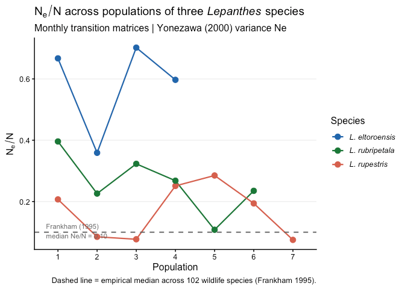

```r
# Summary plot: Ne/N by species and population
ggplot(results_display, aes(x = factor(Population), y = NeN,
                     color = Species, group = Species)) +
  geom_line(linewidth = 0.8) +
  geom_point(size = 3) +
  geom_hline(yintercept = 0.10, linetype = "dashed",
             color = "grey40", linewidth = 0.7) +
  annotate("text", x = 0.7, y = 0.105,
           label = "Frankham (1995)\nmedian Ne/N = 0.10",
           hjust = 0, size = 3, color = "grey40") +
  scale_color_manual(
    values = c("#2166ac", "#1b7837", "#d6604d"),
    labels = c(
      expression(italic("L. eltoroensis")),
      expression(italic("L. rubripetala")),
      expression(italic("L. rupestris"))
    )
  ) +
  labs(
    title    = expression(paste(N[e]/N, " across populations of three ",
                                italic("Lepanthes"), " species")),
    subtitle = "Monthly transition matrices | Yonezawa (2000) variance Ne",
    x        = "Population",
    y        = expression(N[e]/N),
    color    = "Species",
    caption  = "Dashed line = empirical median across 102 wildlife species (Frankham 1995)."
  ) +
  theme_classic(base_size = 12) +
  theme(
    plot.title    = element_text(face = "bold"),
    legend.text   = element_text(face = "italic"),
    panel.grid.major.y = element_line(color = "grey92", linewidth = 0.4)
  )
```

```r
# How many populations have Ne < 50 (Wright drift threshold)?
results_display %>%
  mutate(
    Drift_risk = ifelse(Ne_at_census < 50, "HIGH (Ne < 50)", "lower")
  ) %>%
  select(Species, Population, NeN, Ne_at_census, Drift_risk) %>%
  knitr::kable(
    col.names = c("Species", "Pop", "Ne/N", "Estimated Ne", "Drift risk"),
    escape    = FALSE,
    caption   = "Estimated Ne assuming a census size of N = 40, representative
                 of a large Lepanthes population (Tremblay & Ackerman 2001).
                 Ne < 50 indicates populations where genetic drift dominates
                 over natural selection (Wright 1931; Franklin 1980)."
  )
```

Estimated Ne assuming a census size of N = 40, representative of a large Lepanthes population (Tremblay & Ackerman 2001). Ne < 50 indicates populations where genetic drift dominates over natural selection (Wright 1931; Franklin 1980).

| Species | Pop | Ne/N | Estimated Ne | Drift risk |
| --- | --- | --- | --- | --- |
| *L. rupestris* | 1 | 0.207 | 8.3 | HIGH (Ne < 50) |
| *L. rupestris* | 2 | 0.085 | 3.4 | HIGH (Ne < 50) |
| *L. rupestris* | 3 | 0.077 | 3.1 | HIGH (Ne < 50) |
| *L. rupestris* | 4 | 0.251 | 10.0 | HIGH (Ne < 50) |
| *L. rupestris* | 5 | 0.285 | 11.4 | HIGH (Ne < 50) |
| *L. rupestris* | 6 | 0.194 | 7.7 | HIGH (Ne < 50) |
| *L. rupestris* | 7 | 0.075 | 3.0 | HIGH (Ne < 50) |
| *L. rubripetala* | 1 | 0.396 | 15.8 | HIGH (Ne < 50) |
| *L. rubripetala* | 2 | 0.226 | 9.0 | HIGH (Ne < 50) |
| *L. rubripetala* | 3 | 0.323 | 12.9 | HIGH (Ne < 50) |
| *L. rubripetala* | 4 | 0.268 | 10.7 | HIGH (Ne < 50) |
| *L. rubripetala* | 5 | 0.108 | 4.3 | HIGH (Ne < 50) |
| *L. rubripetala* | 6 | 0.235 | 9.4 | HIGH (Ne < 50) |
| *L. eltoroensis* | 1 | 0.667 | 26.7 | HIGH (Ne < 50) |
| *L. eltoroensis* | 2 | 0.359 | 14.4 | HIGH (Ne < 50) |
| *L. eltoroensis* | 3 | 0.702 | 28.1 | HIGH (Ne < 50) |
| *L. eltoroensis* | 4 | 0.597 | 23.9 | HIGH (Ne < 50) |

## 7.1 Key conservation messages

# 8 Brief overview of the other two functions

## 8.1 Ne_clonal_Y2000

Use this function when **all reproduction is clonal** ($d_i = 1$ for all stages). This implements Equations 10–11 of Yonezawa et al. (2000):

$$N_e = \frac{N}{(1 - \bar{u^2}) \cdot L},
\quad
N_y = \frac{N}{1 - \bar{u^2}}$$

The clonal model is simpler than the general Equation 6 because sexual reproductive variance does not enter. It is the appropriate model for populations maintained entirely by vegetative reproduction (e.g., many ferns, some grasses, clonal shrubs).

```r
Ne_clonal <- Ne_clonal_Y2000(
  T_mat      = MatU,
  F_vec      = MatF[1, ],
  D          = D,
  show_Ny    = TRUE,       # also compute annual effective size
  population = "fully clonal population"
)
```

## 8.2 Ne_mixed_Y2000

Use this function when **stages differ in their mix of sexual and clonal reproduction** ($0 \leq d_i \leq 1$). This implements the full Equation 6 of Yonezawa et al. (2000), including the clonal reproductive variance term $Avr(A\delta)$.

An important property: under Poisson defaults ($V_c/\bar{c} = V_k/\bar{k} = 1$, $a = 0$), the clonal fraction $d_i$ has **no effect** on $N_e/N$. The clonal fraction only influences $N_e$ when clonal output is more variable than sexual output ($V_c/\bar{c} > V_k/\bar{k}$), which is biologically realistic for many clonal plants.

```r
Ne_mixed <- Ne_mixed_Y2000(
  T_mat      = MatU,
  F_vec      = MatF[1, ],
  D          = D,
  d          = c(0.0, 0.0, 0.5),  # stage 3 is 50% clonal
  Vc_over_c  = c(1, 1, 2),        # stage 3 has super-Poisson clonal variance
  population = "mixed orchid"
)
```

# 10 References

- Caswell H. (2001). *Matrix Population Models*, 2nd ed. Sinauer Associates.
- Frankham R. (1995). Effective population size/adult population size ratios in wildlife: a review. *Genetical Research* **66**: 95–107.
- Lande R. (1995). Mutation and conservation. *Conservation Biology* **9**: 782–791.
- Luer C.A. (1986). Icones Pleurothallidinarum I. *Monograph in Systematic Botany* **15**.
- Orive M.E. (1993). Effective population size in organisms with complex life histories. *Theoretical Population Biology* **44**: 316–340.
- Salguero-Gómez R. et al. (2015). The COMPADRE Plant Matrix Database. *Journal of Ecology* **103**: 202–218.
- Tremblay R.L. & Ackerman J.D. (2001). Gene flow and effective population size in *Lepanthes* (Orchidaceae): a case for genetic drift. *Biological Journal of the Linnean Society* **72**: 47–62.
- Wright S. (1931). Evolution in Mendelian populations. *Genetics* **16**: 97–159.
- Yonezawa K., Ishida T. & Iwata H. (2000). Formulation and estimation of the effective size of stage-structured populations. *Evolution* **54**: 2007–2013.